# lab7

Patryk Tokarski

### Stwórzcie wykres funkcji gęstości dla zmiennej cena w każdej z grup szlifu diamentów (zbiór danych diamonds). Wykres ma być poniższej postaci.

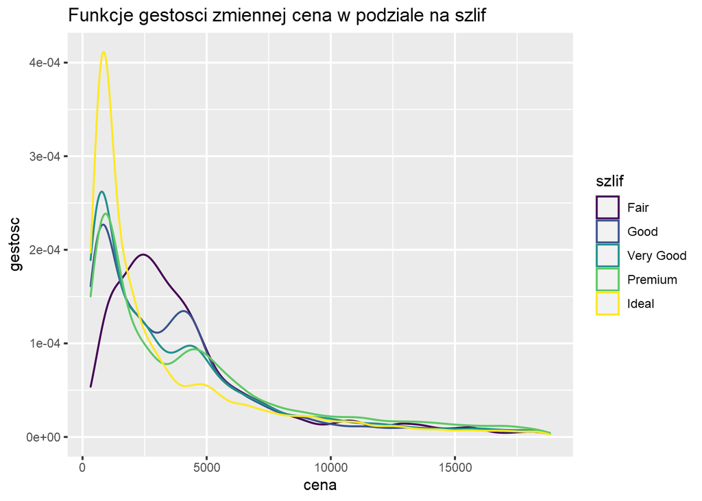

```r
library(ggplot2)
ggplot(diamonds, aes(price, color = cut))+
  geom_density()+
  labs(title = "Funkcje gestosci zmiennej cena w podziale na szlif",
       x = 'cena',
       y = 'gestosc',
       color = 'szlif')
```

### Ze zbioru danych gapminder (pakiet o tej samej nazwie) wybierzcie obserwacje które dotyczą 2002 roku oraz stwórzcie wykres poniższej postaci. Kolor którym wypełnione są wykresy ramka wąsy to jasnoniebieski, ramki są koloru czerwonego.

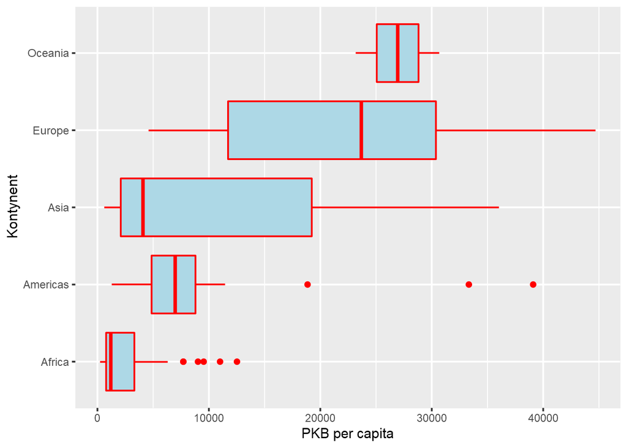

```r
library(gapminder)
data <- gapminder[gapminder$year == 2002, ]

ggplot(data, aes(x = gdpPercap, y = continent))+
  geom_boxplot(col = "red", fill = "lightblue")+
  labs(x = "PKB per capita", y = "Kontynent")
```

### Stwórzcie wykres zależności między transformacją logarytmiczną zmiennej oznaczającej wagę zwierzęcia, a transformacją logarytmiczną zmiennej oznaczającej masę mózgu. Pokoloruj punkty na wykresie za pomocą zmiennej oznaczającej liczbę godzin snu

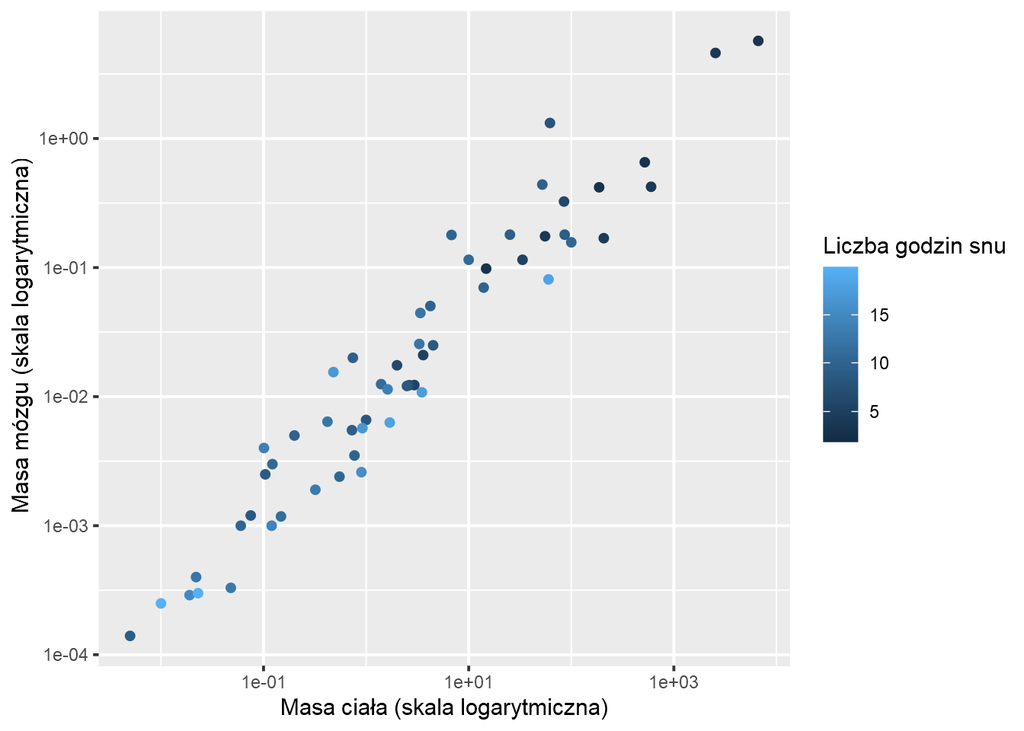

```r
ggplot(msleep, aes(x = bodywt, y = brainwt, color = sleep_total))+
  geom_point()+
  scale_x_log10()+
  scale_y_log10()+
  labs(x = "Masa ciała (skala logarytmiczna)",
       y = "Masa mózgu (skala logarytmiczna)",
       color = "Liczba godzin snu")
```

### Narysujcie wykres liniowy, na którym będą też wyrysowane punkty. Zależności pomiędzy liczbą nieprzespanych przez zwierzę godzin (awake), a liczbą jego godzin snu w fazie REM(sleep_rem), linie mają być narysowane dla różnych rodzajów odżywania zwierzęcia. (zbiór danych msleep)

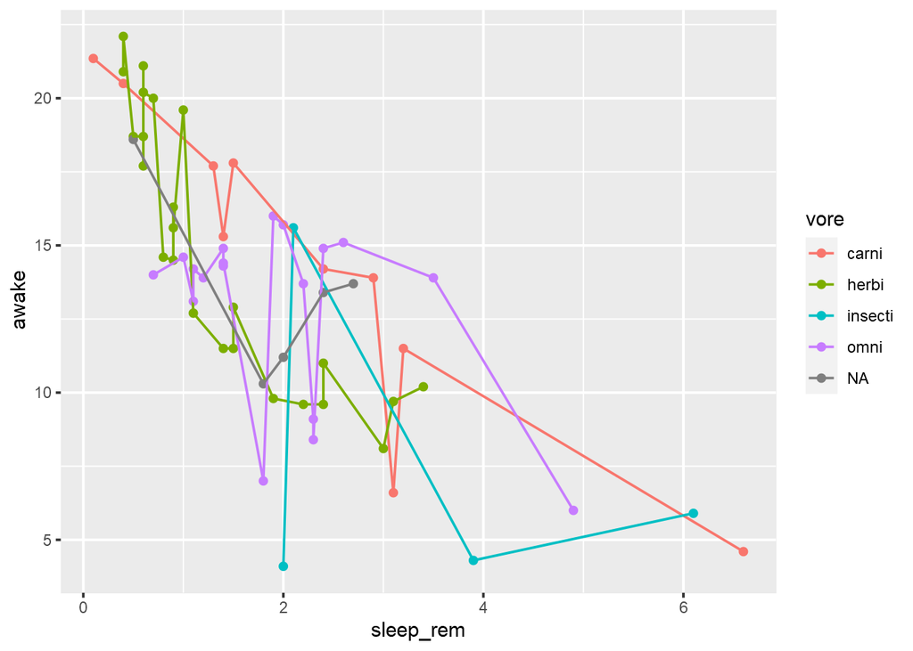

```r
ggplot(msleep, aes(x = sleep_rem, y = awake, colour = vore))+
  geom_point()+
  geom_line()
```

### Na podstawie zbioru danych movies z pakietu ggplot2movies stwórzcie wykres, na którym przedstawione będą tylko filmy sklasyfikowane jako PG oraz PG-13 z lat od 2000 do 2005. Ma być to wykres ramka wąsy, jak ten przedstawiony poniżej.

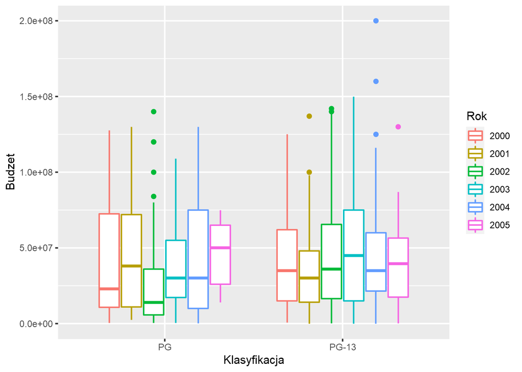

```r
library(ggplot2movies)
data <- movies[movies$mpaa %in% c("PG", "PG-13") &
                 movies$year >=2000 & movies$year <= 2005, ]
ggplot(data, aes(x = mpaa, y = budget, colour = factor(year)))+
  geom_boxplot()+
  labs(x = 'Klasyfikacja', y='Budzet', colour = 'Rok')
```

### Narysuj siatkę wykresów, którą tworzymy za pomocą zmiennej year i drv

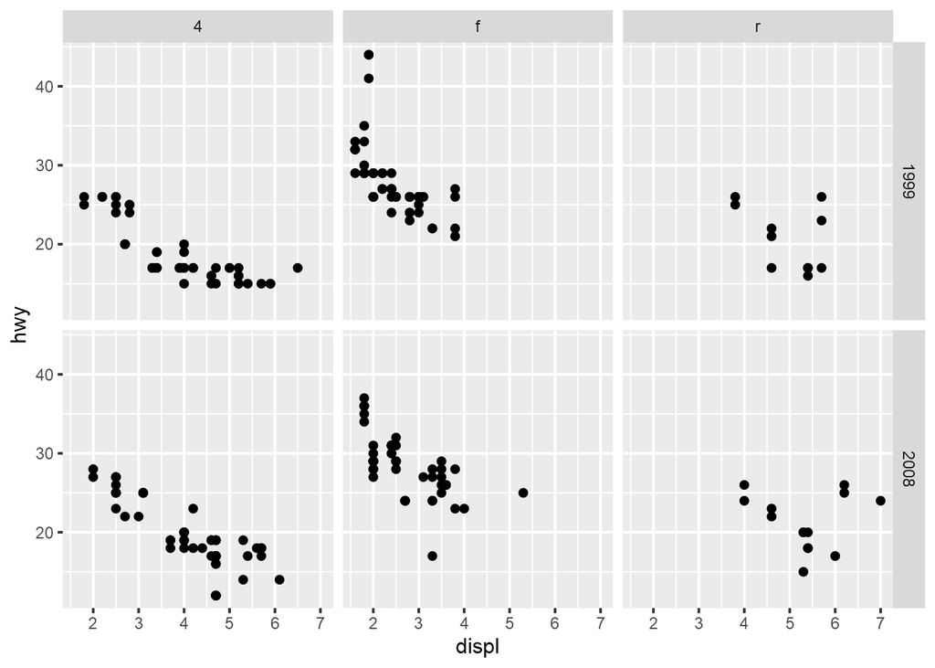

```r
ggplot(mpg, aes(x = displ, y = hwy))+
  geom_point()+
  facet_grid(year ~ drv)
```